# Look Over Korean Immigrants Life Style!

Daehan Park, Seungjin Lee, Byeol Yeo, Jinhyuk Choi, Yoonyoung Choi at Bigdata Club BOAZ in Korea

## 0. Data Preparation

```r
suppressMessages({
  library(data.table)
  library(dplyr)
  library(tidyr)
  library(ggplot2)
  library(RColorBrewer)
  library(maps)
})

path <- "N:\\My_Documents\\2013 USA Census\\WD\\Data"
cols <- c("COW", "POBP", "ANC1P", "RAC2P", "DECADE", "ST", "SEX", "YOEP", "AGEP", "INDP", "SCHL", "WKHP", "PINCP")
pusa <- fread(paste(path, "ss13pusa.csv", sep = "\\"), select = cols)
```

```
##
Read 0.0% of 1613672 rows
Read 34.1% of 1613672 rows
Read 68.2% of 1613672 rows
Read 1613672 rows and 13 (of 283) columns from 1.416 GB file in 00:02:44
```

```r
pusb <- fread(paste(path, "ss13pusb.csv", sep = "\\"), select = cols)
```

```
##
Read 0.0% of 1519123 rows
Read 35.5% of 1519123 rows
Read 70.4% of 1519123 rows
Read 1519123 rows and 13 (of 283) columns from 1.333 GB file in 00:02:35
```

```r
pus <- bind_rows(pusa, pusb)
rm(pusa, pusb)
gc()
```

```
##            used  (Mb) gc trigger  (Mb) max used  (Mb)
## Ncells   502785  26.9     940480  50.3   592000  31.7
## Vcells 21060942 160.7   54447488 415.5 45221416 345.1
```

```r
# COW(Class of worker)
pus$COW <- factor(pus$COW)
levels(pus$COW) <- c("Private profit", "Private non-profit", "Local government", "State government", "Federal government", "Self-employed", "Self-employed", "Working without pay", "Unemployed")

# DECADE(Decade of entry)
pus$DECADE <- factor(pus$DECADE)
levels(pus$DECADE) <- c("~1950's", "1950's", "1960's", "1970's", "1980's", "1990's", "2000's~")

# ST(State Code)
pus$ST <- as.factor(pus$ST)
levels(pus$ST) <- c("Alabama", "Alaska", "Arizona", "Arkansas", "California", "Colorado", "Connecticut",
                 "Delaware", "District of Columbia", "Florida", "Georgia", "Hawaii", "Idaho", "Illinois",
                 "Indiana", "Iowa", "Kansas", "Kentucky", "Louisiana", "Maine", "Maryland", "Massachusetts",
                 "Michigan", "Minnesota", "Mississippi", "Missouri", "Montana", "Nebraska", "Nevada",
                 "New Hampshire", "New Jersey", "New Mexico", "New York", "North Carolina", "North Dakota",
                 "Ohio", "Oklahoma", "Oregon", "Pennsylvania", "Rhode Island", "South Carolina", "South Dakota",
                 "Tennessee", "Texas", "Utah", "Vermont", "Virginia", "Washington", "West Virginia",
                 "Wisconsin", "Wyoming", "Puerto Rico")

# SEX
pus$SEX <- factor(pus$SEX)
levels(pus$SEX) <- c("Male", "Female")

# INDP(Industry recode for 2013 and later based on 2012 IND codes)
pus$INDP <- ifelse(pus$INDP >= 170 & pus$INDP <= 290, 170, pus$INDP)
pus$INDP <- ifelse(pus$INDP >= 370 & pus$INDP <= 490, 370, pus$INDP)
pus$INDP <- ifelse(pus$INDP >= 570 & pus$INDP <= 770, 570, pus$INDP)
pus$INDP <- ifelse(pus$INDP >= 1070 & pus$INDP <= 3990, 1070, pus$INDP)
pus$INDP <- ifelse(pus$INDP >= 4070 & pus$INDP <= 6390, 4070, pus$INDP)
pus$INDP <- ifelse(pus$INDP >= 6470 & pus$INDP <= 6780, 6470, pus$INDP)
pus$INDP <- ifelse(pus$INDP >= 6870 & pus$INDP <= 7190, 6870, pus$INDP)
pus$INDP <- ifelse(pus$INDP >= 7270 & pus$INDP <= 7790, 7270, pus$INDP)
pus$INDP <- ifelse(pus$INDP >= 7860 & pus$INDP <= 7890, 7860, pus$INDP)
pus$INDP <- ifelse(pus$INDP >= 7970 & pus$INDP <= 8290, 7970, pus$INDP)
pus$INDP <- ifelse(pus$INDP >= 8370 & pus$INDP <= 8470, 8370, pus$INDP)
pus$INDP <- ifelse(pus$INDP %in% c(8660, 8680, 8690), 8370, pus$INDP)
pus$INDP <- ifelse(pus$INDP >= 8770 & pus$INDP <= 9290, 8370, pus$INDP)
pus$INDP <- ifelse(pus$INDP %in% c(8560, 8570, 8580, 8590, 8670), 8560, pus$INDP)
pus$INDP <- ifelse(pus$INDP >= 9370 & pus$INDP <= 9590, 9370, pus$INDP)
pus$INDP <- ifelse(pus$INDP >= 9670 & pus$INDP <= 9870, 9670, pus$INDP)
pus$INDP <- ifelse(pus$INDP >= 9920, 9920, pus$INDP)
pus$INDP <- factor(pus$INDP)
levels(pus$INDP) <- c("Agriculture, Forestry, Fishing, Hunting", "Mining", "Utilities, Construction",
              "Manufacturing", "Trade, Logistic", "Information, Communications", "Finance",
              "Professional", "Education", "Health", "Other Services",
              "Arts, Entertainment", "Public Administration", "Military", "Unemployed"
            )

# SCHL(Educational attainment)
pus$SCHL <- ifelse(pus$SCHL <= 16, 16, pus$SCHL)
pus$SCHL <- ifelse(pus$SCHL >= 17 & pus$SCHL <= 19, 19, pus$SCHL)
pus$SCHL <- factor(pus$SCHL)
levels(pus$SCHL) <- c("High school or lower", "Some college", "Associate", "Bachelor", "Master", "Professional", "Doctorate")
```

## 1. Comparing different immigrants group for working hours per week

We would like to know that there are significant differences for working hours among ethnic immigrants group. According to the OECD statistics, Koreans are working 1.2 times longer on average than other developed countries.(https://data.oecd.org/emp/hours-worked.htm)

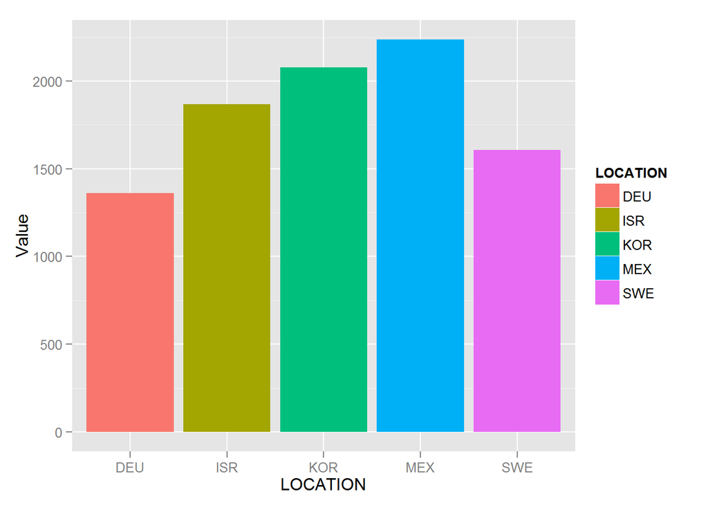

```r
# OECD Data
oecd.wh <- read.csv("N:\\My_Documents\\2013 USA Census\\WD\\History\\OECD_Work hour.csv")
oecd.wh <- filter(oecd.wh, LOCATION %in% c("DEU", "ISR", "KOR", "MEX", "SWE"))

ggplot(oecd.wh, aes(x=LOCATION)) + geom_bar(aes(y=Value, fill=LOCATION), stat="identity")
```

In the USA census data, we can find Korean immigrants are still number 2 among five ethnic immigrants group.

```r
WH <- pus[, c("COW", "POBP", "ANC1P", "WKHP")]
WH$NATION <- rep(NA)
WH$NATION <- ifelse(WH$POBP == 217 & WH$ANC1P ==750, "Korea", WH$NATION)
WH$NATION <- ifelse(WH$POBP == 214 & WH$ANC1P == 419, "Israel", WH$NATION)
WH$NATION <- ifelse(WH$POBP == 110 & WH$ANC1P == 32, "German", WH$NATION)
WH$NATION <- ifelse(WH$POBP == 303 & WH$ANC1P == 210, "Mexico", WH$NATION)
WH$NATION <- ifelse(WH$POBP == 136 & WH$ANC1P == 89, "Sweden", WH$NATION)
```

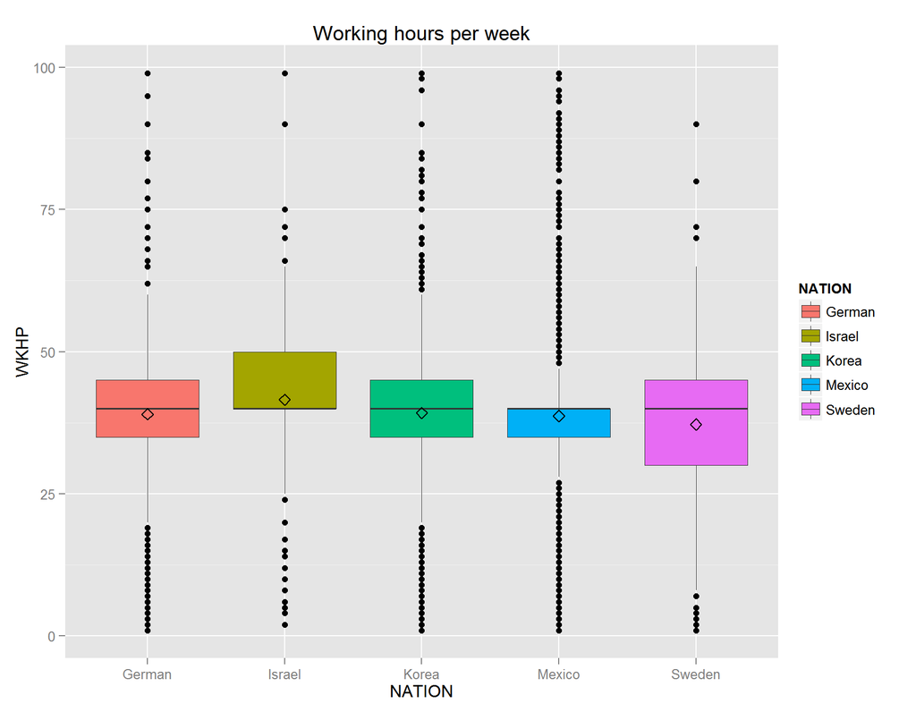

```r
ggplot(filter(WH, is.na(NATION)==F) , aes(x=NATION, y=WKHP)) +
    geom_boxplot(aes(fill=NATION), size=0.3) +
    stat_summary(fun.y=mean, geom="point", shape=23, size=3) +
    ggtitle("Working hours per week")
```

```r
WH %>%
    group_by(NATION) %>%
        select(WKHP) %>%
            summarise(Avg.Work.Hour=mean(WKHP, na.rm=T))
```

```
## Source: local data frame [6 x 2]
##
##   NATION Avg.Work.Hour
## 1 German      39.00629
## 2 Israel      41.54483
## 3  Korea      39.23813
## 4 Mexico      38.70697
## 5 Sweden      37.20426
## 6     NA      37.84995
```

### Self employed group

Especially, in self-employed groups there are more significant distributional differences. Certainly, **Israel** and **Korean** immigrants’ distribution converge in higher working hours than other ethnic groups.

```r
WHSE <- filter(WH, COW == "Self-employed")
```

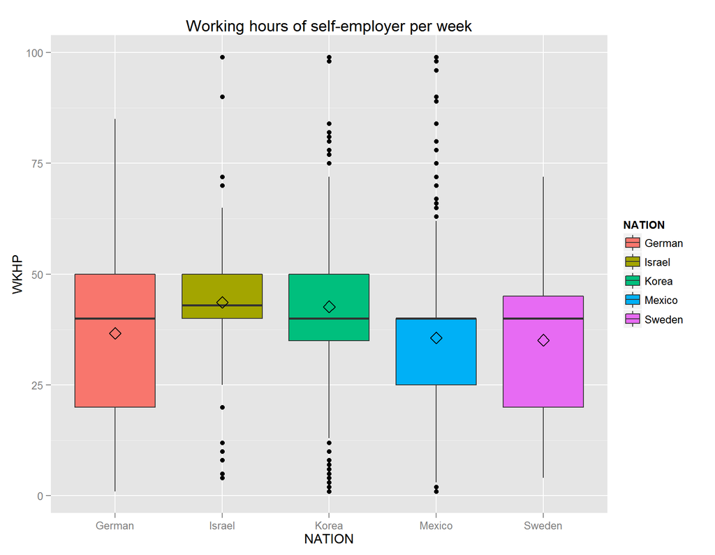

```r
ggplot(filter(WHSE, is.na(NATION)==F), aes(x= NATION, y= WKHP)) +
    geom_boxplot(aes(fill = NATION), alph= 0.5) +
    stat_summary(fun.y=mean, geom="point", shape=23, size=4) +
    ggtitle("Working hours of self-employer per week")
```

```r
WHSE %>%
    group_by(NATION) %>%
        select(WKHP) %>%
            summarise(Avg.Work.Hour=mean(WKHP, na.rm=T))
```

```
## Source: local data frame [6 x 2]
##
##   NATION Avg.Work.Hour
## 1 German      36.62592
## 2 Israel      43.63291
## 3  Korea      42.63479
## 4 Mexico      35.63629
## 5 Sweden      35.09677
## 6     NA      37.59620
```

## 2. A study on the periodic characteristics of korean immigrants?!

### Age Distribution by Decade on Their Immigrants Year

We divide Korean immigrants by decade on their immigrants year. Using this, we look over their age distribution. In natural, More far from their immigrants year, more older.

```r
pus.kor <- filter(pus, POBP == 217 & RAC2P == 49) # POBP : 217(Korea), RAC3P : 49(Korean)
```

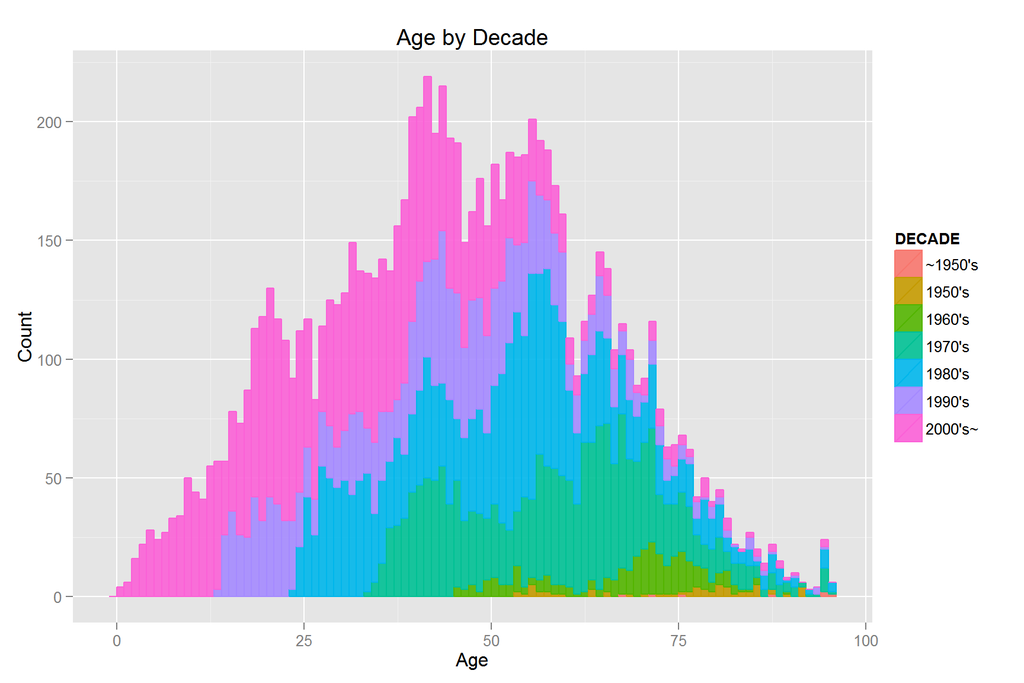

```r
# DECADE
ggplot(pus.kor, aes(AGEP, group=DECADE)) +
  geom_bar(aes(colour=DECADE, fill=DECADE), binwidth=1, alpha=0.9) +
  xlab("Age") + ylab("Count") + ggtitle("Age by Decade")
```

```r
table(pus.kor$DECADE)
```

```
##
## ~1950's  1950's  1960's  1970's  1980's  1990's 2000's~
##       7      62     301    1816    2287    1781    3101
```

### Living State

Most korean immigrants live in **California**.

```r
all_state <- map_data("state")
data <- as.data.frame(prop.table(table(pus.kor$ST)))
data$state <- sort(tolower(c("district of columbia","Puerto Rico", state.name)))
all_state$freq <- data$Freq[match(all_state$region, data$state)]*100
```

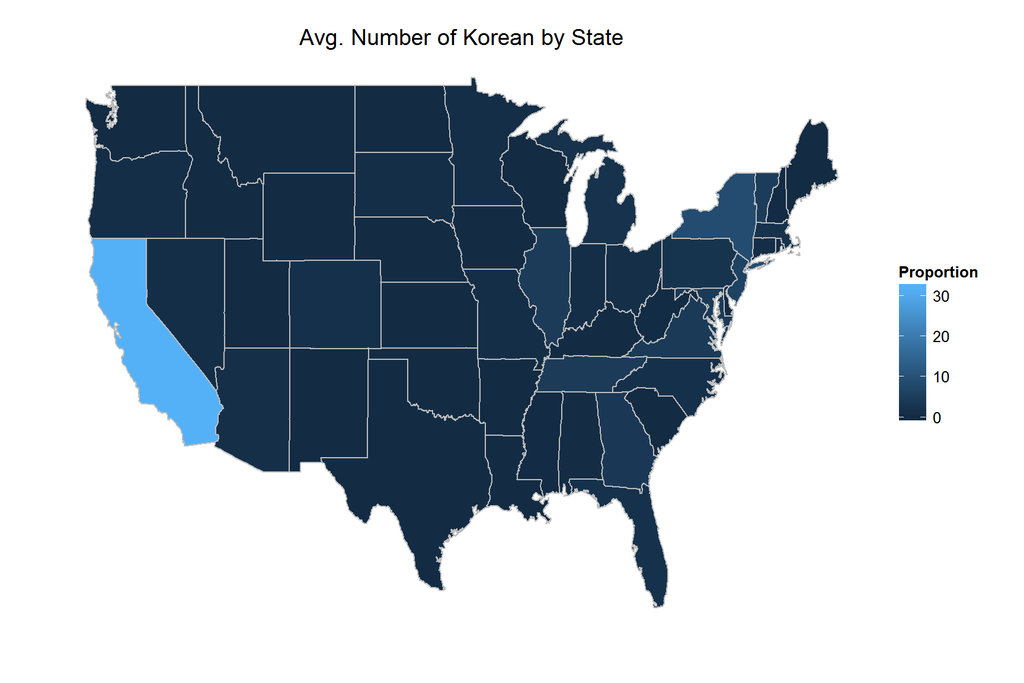

```r
p <- ggplot(all_state, aes(x=long, y=lat, group=group)) +
      geom_polygon(aes(fill=freq), colour="gray")
p <- p + theme(strip.background = element_blank(),
               strip.text.x     = element_blank(),
               axis.text.x      = element_blank(),
               axis.text.y      = element_blank(),
               axis.ticks       = element_blank(),
               axis.line        = element_blank(),
               panel.background = element_blank(),
               panel.border     = element_blank(),
               panel.grid       = element_blank(),
               legend.position  = "right") +
          scale_fill_continuous(name="Proportion") +
          xlab("") + ylab("") + ggtitle("Avg. Number of Korean by State")
p
```

```r
st.df <- pus.kor %>% group_by(ST) %>% summarise(Count=n()) %>% arrange(desc(Count))
st.df$Prop <- round(st.df$Count / sum(st.df$Count) * 100, 1)
head(st.df, 20)
```

```
## Source: local data frame [20 x 3]
##
##                ST Count Prop
## 1      California  3007 32.1
## 2        New York   822  8.8
## 3      New Jersey   583  6.2
## 4        Virginia   452  4.8
## 5           Texas   414  4.4
## 6        Illinois   408  4.4
## 7        Maryland   378  4.0
## 8      Washington   376  4.0
## 9         Georgia   351  3.8
## 10   Pennsylvania   235  2.5
## 11  Massachusetts   195  2.1
## 12       Michigan   187  2.0
## 13        Florida   164  1.8
## 14 North Carolina   151  1.6
## 15       Colorado   144  1.5
## 16         Hawaii   133  1.4
## 17        Arizona   118  1.3
## 18           Ohio   118  1.3
## 19         Nevada   100  1.1
## 20        Indiana    87  0.9
```

### 1950~60’s

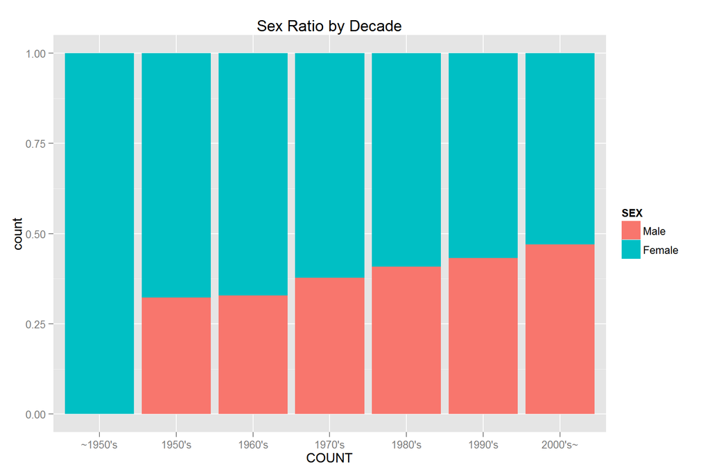

```r
ggplot(pus.kor, aes(x=DECADE)) +
    geom_bar(aes(fill=SEX), position="fill") +
    xlab("COUNT") + ggtitle("Sex Ratio by Decade")
```

Also, we would like to know immigrants age distribution at the time when they immigrant. This graph shows Korean immigrants age group at the time when they immigrant year. Before observing the data, we divided age group by decade. The graph shows striking pattern before **1950’s** and **1950’s**. That time, lots of youth came in USA. It seems that it is influenced by the Korea War. However, there are some limitations. The data comes from 2013 USA census, so there are few or no sampling targets from elder people.

```r
pus.kor$AGEY <- pus.kor$AGEP - (2013-pus.kor$YOEP) + 2
pus.kor$AGEG <- rep(0, nrow(pus.kor))
pus.kor$AGEG <- ifelse(pus.kor$AGEY >= 0 & pus.kor$AGEY < 10, 0, pus.kor$AGEG)
pus.kor$AGEG <- ifelse(pus.kor$AGEY >= 10 & pus.kor$AGEY < 20, 1, pus.kor$AGEG)
pus.kor$AGEG <- ifelse(pus.kor$AGEY >= 20 & pus.kor$AGEY < 30, 2, pus.kor$AGEG)
pus.kor$AGEG <- ifelse(pus.kor$AGEY >= 30 & pus.kor$AGEY < 40, 3, pus.kor$AGEG)
pus.kor$AGEG <- ifelse(pus.kor$AGEY >= 40 & pus.kor$AGEY < 50, 4, pus.kor$AGEG)
pus.kor$AGEG <- ifelse(pus.kor$AGEY >= 50 & pus.kor$AGEY < 60, 5, pus.kor$AGEG)
pus.kor$AGEG <- ifelse(pus.kor$AGEY >= 60, 6, pus.kor$AGEG)
pus.kor$AGEG <- factor(pus.kor$AGEG)
levels(pus.kor$AGEG) <- c("0's", "10's", "20's", "30's", "40's", "50's", "60's~")
```

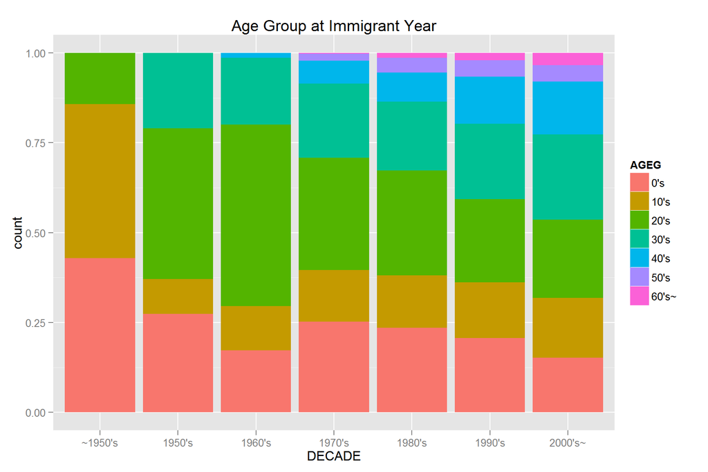

```r
ggplot(pus.kor, aes(x=DECADE)) +
    geom_bar(aes(fill=AGEG), position="fill") +
    ggtitle("Age Group at Immigrant Year")
```

```r
table(pus.kor$DECADE,pus.kor$AGEG)
```

```
##
##           0's 10's 20's 30's 40's 50's 60's~
##   ~1950's   3    3    1    0    0    0     0
##   1950's   17    6   26   13    0    0     0
##   1960's   52   37  152   56    4    0     0
##   1970's  458  261  567  374  117   34     5
##   1980's  537  335  668  437  184   95    31
##   1990's  369  275  412  373  234   81    37
##   2000's~ 473  515  674  735  455  142   107
```

This graph shows that Korean immigrants’s industry distribution by decade. In 1950s, **Mining**, **Utility and Construction** are stronger in ratio than that of other decades. In 1960s, health care industry seems to be outnumbered. This is because specialized jobs are required by America Society.

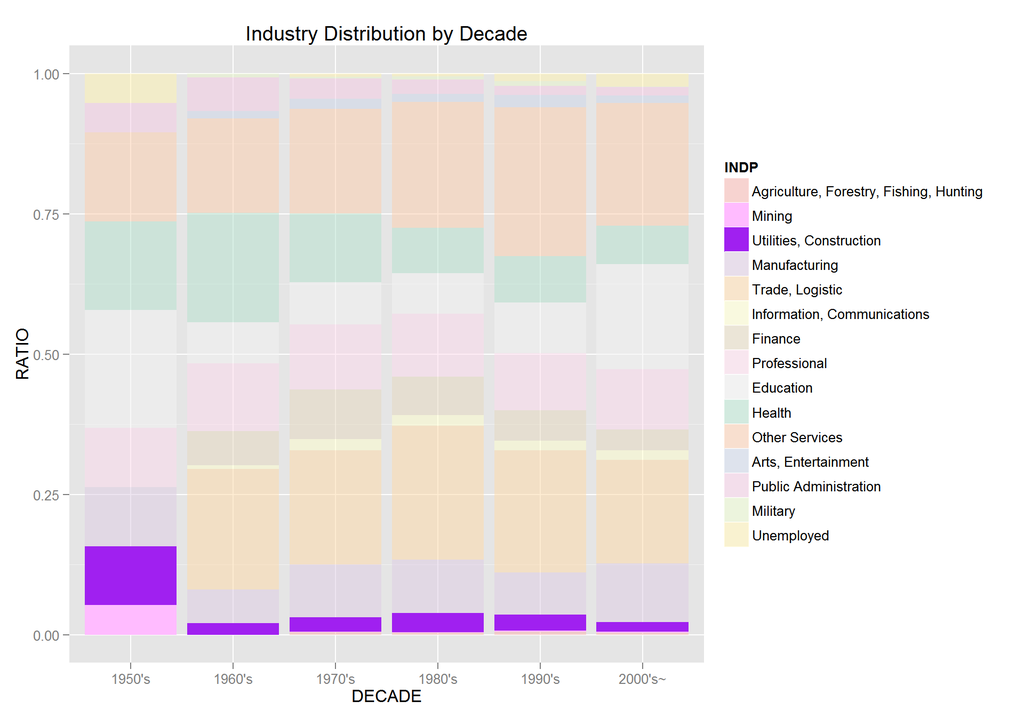

```r
color <- scales::alpha(c(brewer.pal(n = 9, name = "Pastel1"), brewer.pal(n = 6, name = "Pastel2")), 0.5)
color[2:3] <- c("plum1", "purple")
ggplot(filter(pus.kor, is.na(INDP) == F), aes(x = DECADE)) +
  geom_bar(aes(fill = INDP), position="fill") +
  scale_fill_manual(values = color) +
  ylab("RATIO") + ggtitle("Industry Distribution by Decade")
```

The First graph shows that advanced degree(higher than master) people has quite substantial portion of the population. At the second graph, We can guess that there were lots of specialized jobs’ employees especially in **health care**.

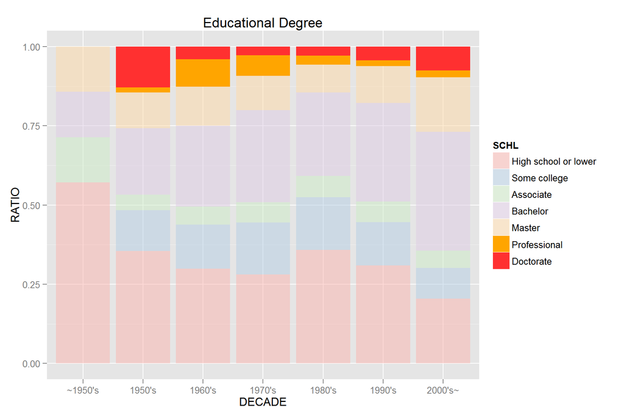

```r
color <- scales::alpha(brewer.pal(n = 7, name = "Pastel1"), 0.5)
color[6:7] <- c("orange", "firebrick1")
ggplot(filter(pus.kor, is.na(SCHL) == F & AGEP >= 35), aes(x=DECADE)) +
  geom_bar(aes(fill=SCHL), position="fill") +
  scale_fill_manual(values = color) +
  ylab("RATIO") + ggtitle("Educational Degree")
```

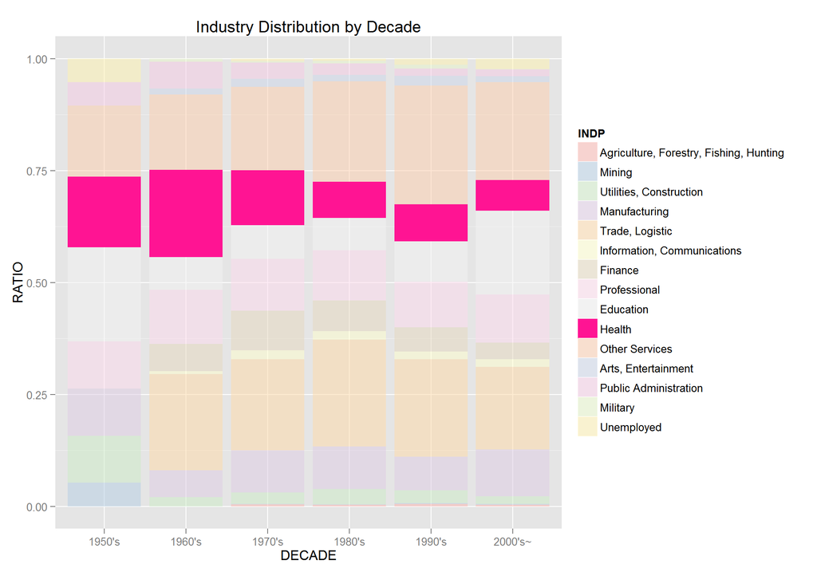

```r
color <- scales::alpha(c(brewer.pal(n = 9, name = "Pastel1"), brewer.pal(n = 6, name = "Pastel2")), 0.5)
color[10] <- "deeppink"
ggplot(filter(pus.kor, is.na(INDP) == F), aes(x = DECADE)) +
  geom_bar(aes(fill = INDP), position="fill") +
  scale_fill_manual(values = color) +
  ylab("RATIO") + ggtitle("Industry Distribution by Decade")
```

### 1980~90’s

In 1980~90’s, the number of people engaged in **trade, logistic** and **other service** are outnumbered by the number of people in other decades.

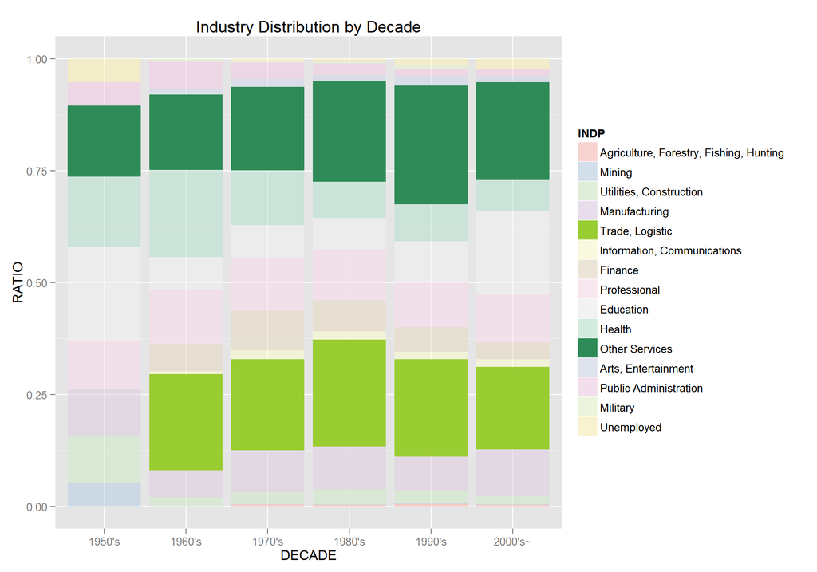

```r
color <- scales::alpha(c(brewer.pal(n = 9, name = "Pastel1"), brewer.pal(n = 6, name = "Pastel2")), 0.5)
color[c(5,11)] <- c("yellowgreen", "seagreen")
ggplot(filter(pus.kor, is.na(INDP) == F), aes(x = DECADE)) +
  geom_bar(aes(fill = INDP), position="fill") +
  scale_fill_manual(values = color) +
  ylab("RATIO") + ggtitle("Industry Distribution by Decade")
```

### 2000’s

In 2000s, **education** occupation highly increased.

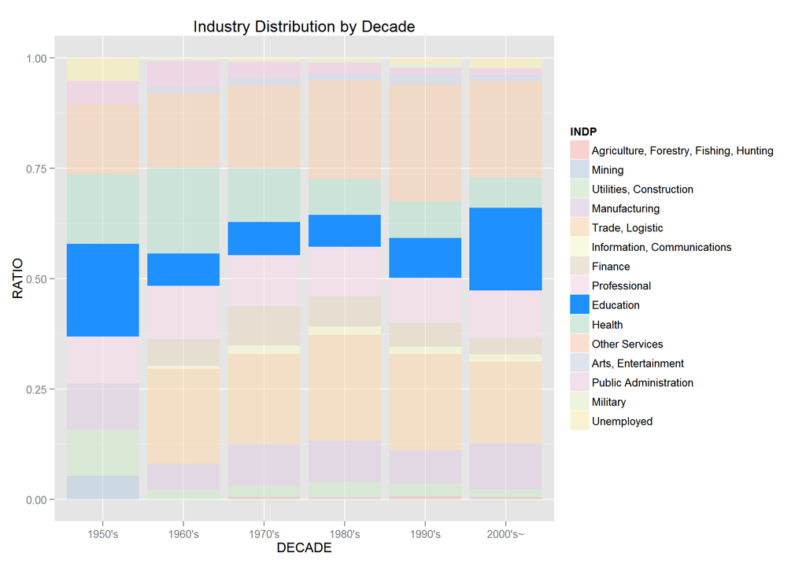

```r
color <- scales::alpha(c(brewer.pal(n = 9, name = "Pastel1"), brewer.pal(n = 6, name = "Pastel2")), 0.5)
color[9] <- "dodgerblue"
ggplot(filter(pus.kor, is.na(INDP) == F), aes(x = DECADE)) +
  geom_bar(aes(fill = INDP), position="fill") +
  scale_fill_manual(values = color) +
  ylab("RATIO") + ggtitle("Industry Distribution by Decade")
```

In 2000’s, percentage of higher than **master degree** is higher than any other decades, especially **bachelor degree** is the most highest. And also lower than **highs school or lower degree** percentage is the lowest. It seems that during in past 10 years, total educational levels are upward. (Hypothesis : Studying Person’s will be lower than 35 years old)

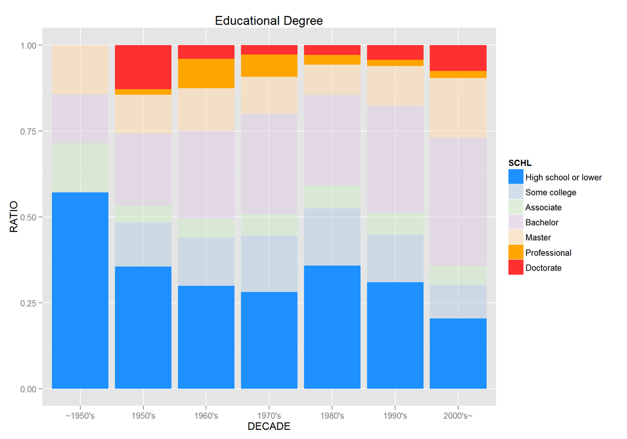

```r
color <- scales::alpha(brewer.pal(n = 7, name = "Pastel1"), 0.5)
color[c(1, 6:7)] <-  c("dodgerblue", "orange", "firebrick1")
ggplot(filter(pus.kor, is.na(SCHL) == F & AGEP >= 35), aes(x=DECADE)) +
  geom_bar(aes(fill=SCHL), position="fill") +
  scale_fill_manual(values = color) +
  ylab("RATIO") + ggtitle("Educational Degree")
```

### Average Income in Accordance with The Immigration Period by Industries

The 1950’s People have the highest income in **Mining**. Overall, there are high income in **Public Administration**, **Health** and **Manufacturing**. Especially, there is the best high in 1960’s. It sounds obvious, but they have long carrer.

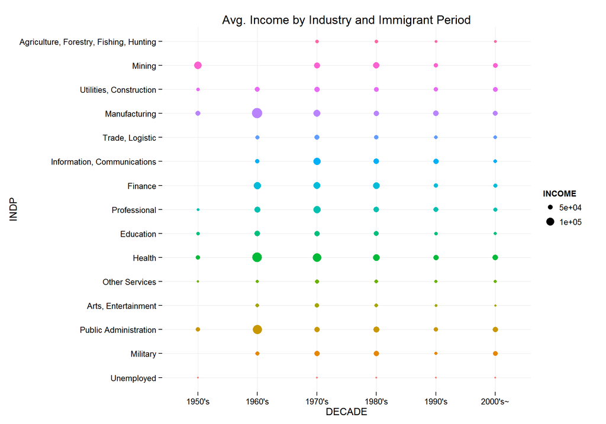

```r
income.df <- pus.kor %>% filter(is.na(INDP) == F) %>% group_by(DECADE, INDP) %>% summarise(INCOME = mean(PINCP))

income.df$INDP <- factor(income.df$INDP, levels = levels(income.df$INDP)[length(levels(income.df$INDP)):1])
ggplot(income.df, aes(x=DECADE)) + geom_point(aes(y=INDP, size=INCOME, colour=INDP)) +
  ggtitle("Avg. Income by Industry and Immigrant Period") +
  guides(colour=FALSE) + theme_minimal()
```

```r
income.df$INDP <- factor(income.df$INDP, levels = levels(income.df$INDP)[length(levels(income.df$INDP)):1])
spread(income.df, DECADE, INCOME)
```

```
## Source: local data frame [15 x 7]
##
##                                       INDP   1950's    1960's     1970's
## 1  Agriculture, Forestry, Fishing, Hunting       NA        NA  25933.333
## 2                                   Mining 96000.00        NA  70000.000
## 3                  Utilities, Construction 26750.00  53333.33  61080.000
## 4                            Manufacturing 56800.00 148900.00  83322.650
## 5                          Trade, Logistic       NA  37684.38  52145.415
## 6              Information, Communications       NA  43100.00  89892.000
## 7                                  Finance       NA  92874.44  85473.955
## 8                             Professional 15000.00  71933.33  89224.403
## 9                                Education 30625.00  67181.82  60828.645
## 10                                  Health 44366.67 136630.34 111153.203
## 11                          Other Services 10200.00  22001.20  37258.848
## 12                     Arts, Entertainment       NA  31200.00  44117.391
## 13                   Public Administration 46000.00 120028.89  60862.889
## 14                                Military       NA  36000.00  62050.000
## 15                              Unemployed   140.00        NA   1285.714
## Variables not shown: 1980's (dbl), 1990's (dbl), 2000's~ (dbl)
```